# Coral Wound Healing Analysis: Effects of Damselfish Presence and Wound Size

Hayden Vega & Adrian Stier

2026-05-16

# Overview

## Study Design

**Research Question**: Do damselfish (*Dascyllus flavicaudus*) accelerate coral wound healing rates in *Pocillopora* spp.?

**Experimental Design**:

- **Factors**: Fish presence (Present/Absent) × Wound size (None/Small/Large)
- **Sample size**: 72 coral fragments
- **Duration**: 21 days
- **Location**: Mo’orea, French Polynesia
- **Response variables**:
  - Healing rate (cm²/day)
  - Percent wound closure
  - Binary healing outcome

## Analysis Overview

This document contains:

1. **Data Import & Cleaning**
2. **Exploratory Data Analysis**
3. **Mixed-Effects Models** (healing rate)
4. **Publication Figure Generation**
5. **Model Diagnostics**

# 1. Setup & Data Import

## Load Required Packages

```r
# ==================== Core Packages ====================
library(tidyverse)      # Data wrangling and visualization
library(here)           # Relative file paths
library(janitor)        # Data cleaning

# ==================== Statistical Modeling ====================
library(lme4)           # Linear mixed-effects models
library(glmmTMB)        # Generalized linear mixed models
library(DHARMa)         # Residual diagnostics for GLMMs
library(MuMIn)          # Model selection
library(parameters)     # Model parameter extraction
library(broom.mixed)    # Tidy model outputs
library(ggeffects)      # Marginal effects

# ==================== Visualization ====================
library(ggpubr)         # Publication-ready plots
library(viridis)        # Color palettes
library(patchwork)      # Combine plots
library(gt)             # Publication-quality tables

# ==================== Fonts ====================
library(sysfonts)       # Font management
library(showtext)       # Font rendering

# ==================== Optional: Advanced Models ====================
if (!requireNamespace("gamlss", quietly = TRUE)) {
  install.packages("gamlss")
}
library(gamlss)
library(gamlss.dist)

# Set default theme
theme_set(theme_bw() + theme(panel.grid = element_blank(), plot.background = element_blank()))
```

## Define Color Palettes

```r
# Consistent color schemes for all figures
# Designed for grayscale compatibility

wound_palette <- c(
  "Large" = "#FF8B00",     # Orange
  "Small" = "#be8333",     # Tan
  "No Wound" = "#485900"   # Olive green
)

# Fish palette: Colorblind-safe with high contrast
# Using darker teal and higher-chroma vermillion (Okabe-Ito inspired)
fish_palette <- c(
  "Fish" = "#0072B2",      # Strong blue (colorblind-safe)
  "No Fish" = "#D55E00"    # Vermillion/orange-red (high contrast)
)

# Fill palette for grayscale distinction
fish_fill_palette <- c(
  "Fish" = "#0072B2",      # Strong blue fill
  "No Fish" = "white"      # White fill (open appearance)
)
```

## Import Raw Data

```r
# Import wound closure binary data (healed yes/no)
wound_closure <- read_csv(
  here("data", "fish_regen_mastersheet_wound closure_necrosis_sa - mastersheet.csv")
) %>%
  clean_names()

# Import quantitative healing rate data
percent_closure <- read_csv(
  here("data", "final_wound_size_dascyllus_project - Sheet1.csv")
) %>%
  clean_names()

cat("✓ Data imported successfully\n")
```

```
## ✓ Data imported successfully
```

```r
cat("  - Wound closure binary data:", nrow(wound_closure), "observations\n")
```

```
##   - Wound closure binary data: 72 observations
```

```r
cat("  - Percent closure data:", nrow(percent_closure), "observations\n")
```

```
##   - Percent closure data: 48 observations
```

# 2. Data Preparation

## Treatment Coding Function

```r
#' Convert numeric treatment codes to labeled factors
#'
#' @param df Data frame containing fish and wound columns
#' @return Data frame with properly ordered factor levels
prep_treatments <- function(df) {
  df %>%
    mutate(
      # Convert fish coding: 1 = Fish present, 0 = Fish absent
      fish = ifelse(fish == 1, "Fish", ifelse(fish == 0, "No Fish", fish)),

      # Convert wound size coding: 0 = None, 1 = Small, 2 = Large
      wound = case_when(
        wound == 0 ~ "No Wound",
        wound == 1 ~ "Small",
        wound == 2 ~ "Large",
        TRUE ~ as.character(wound)
      )
    ) %>%
    mutate(
      # Set factor levels in logical order
      fish  = factor(fish, levels = c("No Fish", "Fish")),
      wound = factor(wound, levels = c("No Wound", "Small", "Large"))
    )
}
```

## Clean Wound Closure Data

```r
# Process binary wound closure data
wound_closure_clean <- wound_closure %>%
  filter(!is.na(wound_close), wound_close != "") %>%
  # Standardize "barely healed" responses to "no"
  mutate(wound_close = ifelse(wound_close %in% c("no-barely", "no - barely"), "no", wound_close)) %>%
  mutate(wound_close = ifelse(wound_close == "yes", "Yes", "No")) %>%
  prep_treatments() %>%
  mutate(wound_close = as.character(wound_close))

# Create binary version for GLM modeling
wound_closure_glm <- wound_closure %>%
  filter(!is.na(wound_close), wound_close != "") %>%
  mutate(wound_bin = ifelse(wound_close == "yes", 1, 0)) %>%
  prep_treatments() %>%
  filter(!is.na(fish), !is.na(wound), !is.na(tank)) %>%
  droplevels()

# Quality check: Ensure factors have adequate levels
if (nlevels(wound_closure_glm$fish) < 2 | nlevels(wound_closure_glm$wound) < 2) {
  stop("ERROR: Fish or wound factors have <2 levels. Check input data.")
}

cat("✓ Data cleaning complete\n")
```

```
## ✓ Data cleaning complete
```

```r
cat("  - Binary healing data:", nrow(wound_closure_clean), "corals\n")
```

```
##   - Binary healing data: 48 corals
```

## Clean Healing Rate Data

One fragment (coral #95; No Fish, Small wound, tank 2) exhibited net tissue loss over the experiment: its wound expanded from 1.02 cm² to 2.09 cm² (`percent_healed` = −105%), yielding a negative “healing rate.” This is a qualitatively distinct outcome (wound expansion / partial necrosis) rather than slow healing, so it is excluded from the wound-healing-rate analysis and reported explicitly in the Methods (n = 47 fragments retained for the healing-rate models). The exclusion is disclosed rather than silently filtered, per Referee 1’s emphasis on statistical transparency.

```r
# Process continuous healing rate data.
# Exclude coral #95: wound EXPANDED (1.02 -> 2.09 cm2; percent_healed = -105%).
# This is net tissue loss / necrosis, a different outcome than slow
# healing, not a data-entry error. Exclusion is disclosed in the
# manuscript Methods (n = 47 retained). See Section 4 for the
# interaction LRT and 6b for the censoring sensitivity context.
percent_closure <- percent_closure %>%
  filter(percent_healed >= 0) %>%  # excludes coral #95 (net tissue loss; see note above)
  prep_treatments() %>%
  mutate(tank = as.factor(tank))

# Convert percent to proportion (0-1 scale)
percent_closure$prop <- percent_closure$percent_healed / 100
percent_closure$prop_remaining <- 1 - percent_closure$prop

cat("✓ Healing rate data prepared\n")
```

```
## ✓ Healing rate data prepared
```

```r
cat("  - Valid observations:", nrow(percent_closure), "corals\n")
```

```
##   - Valid observations: 47 corals
```

```r
cat("  - Mean healing rate:", round(mean(percent_closure$healing_rate, na.rm = TRUE), 3), "cm²/day\n")
```

```
##   - Mean healing rate: 0.119 cm²/day
```

## Data Summary

```r
# Cross-tabulation of treatments
cat("\n=== Treatment Sample Sizes ===\n")
```

```
##
## === Treatment Sample Sizes ===
```

```r
print(table(percent_closure$fish, percent_closure$wound))
```

```
##
##           No Wound Small Large
##   No Fish        0    11    12
##   Fish           0    12    12
```

```r
# Calculate healing proportions by treatment
wound_prop <- wound_closure_clean %>%
  group_by(wound, fish) %>%
  summarize(
    n = n(),
    prop_healed = mean(wound_close == "Yes"),
    .groups = "drop"
  )

cat("\n=== Proportion Healed by Treatment ===\n")
```

```
##
## === Proportion Healed by Treatment ===
```

```r
print(wound_prop)
```

```
## # A tibble: 4 × 4
##   wound fish        n prop_healed
##   <fct> <fct>   <int>       <dbl>
## 1 Small No Fish    12       0.583
## 2 Small Fish       12       0.917
## 3 Large No Fish    12       0.417
## 4 Large Fish       12       0.75
```

# 3. Wound Size Characterization

```r
# Summarize initial wound sizes
wounds_avgs <- percent_closure %>%
  group_by(wound) %>%
  summarize(
    mean_size_cm2 = mean(initial_wound_size_cm, na.rm = TRUE),
    sd_size_cm2 = sd(initial_wound_size_cm, na.rm = TRUE),
    n = n(),
    .groups = "drop"
  ) %>%
  filter(wound != "No Wound")

# Display as formatted table
wounds_avgs %>%
  gt() %>%
  tab_header(title = "Initial Wound Size by Treatment") %>%
  fmt_number(columns = c(mean_size_cm2, sd_size_cm2), decimals = 2) %>%
  cols_label(
    wound = "Wound Size",
    mean_size_cm2 = "Mean (cm²)",
    sd_size_cm2 = "SD (cm²)",
    n = "N"
  )
```

Initial Wound Size by Treatment

| Wound Size | Mean (cm²) | SD (cm²) | N |
| --- | --- | --- | --- |
| Small | 1.48 | 0.40 | 23 |
| Large | 3.82 | 1.08 | 24 |

# 4. Statistical Models: Healing Rate

## Model Description

We fit linear mixed-effects models to test how fish presence and wound size affect healing rate (continuous response variable in cm²/day).

**Model structure**: - **Fixed effects**: Fish presence, Wound size, and their interaction - **Random effect**: Tank (accounts for shared tank environment) - **Response**: Healing rate (cm²/day)

## Fit Candidate Models

```r
# All models fit by maximum likelihood (REML = FALSE) so that likelihood
# ratio tests comparing nested fixed-effect structures are valid
# (per reviewer 1 request, RSBL-2026-0177 revision).

# Full model with interaction
rate_full <- lmer(
  healing_rate ~ fish * wound + (1 | tank),
  data = percent_closure,
  REML = FALSE
)

# Additive model (no interaction)
rate_no_interaction <- lmer(
  healing_rate ~ fish + wound + (1 | tank),
  data = percent_closure,
  REML = FALSE
)

# Fish-only model
rate_no_fish <- lmer(
  healing_rate ~ wound + (1 | tank),
  data = percent_closure,
  REML = FALSE
)

# Wound-only model
rate_no_wound <- lmer(
  healing_rate ~ fish + (1 | tank),
  data = percent_closure,
  REML = FALSE
)

cat("✓ Models fitted successfully (ML / REML = FALSE)\n")
```

```
## ✓ Models fitted successfully (ML / REML = FALSE)
```

## Model Comparison: Likelihood Ratio Tests

```r
# Test for interaction effect
lrt_interaction_zero_rate <- anova(rate_no_interaction, rate_full, test = "Chisq")

# Test for fish main effect
lrt_fish_zero_rate <- anova(rate_no_fish, rate_no_interaction, test = "Chisq")

# Test for wound main effect
lrt_wound_zero_rate <- anova(rate_no_wound, rate_no_interaction, test = "Chisq")

# Compile results into table
lrt_table_rate <- tibble(
  Test = c("Interaction (Fish × Wound)", "Fish Effect", "Wound Effect"),
  ChiSq = c(
    lrt_interaction_zero_rate$Chisq[2],
    lrt_fish_zero_rate$Chisq[2],
    lrt_wound_zero_rate$Chisq[2]
  ),
  Df = c(
    lrt_interaction_zero_rate$Df[2],
    lrt_fish_zero_rate$Df[2],
    lrt_wound_zero_rate$Df[2]
  ),
  p_value = c(
    lrt_interaction_zero_rate$`Pr(>Chisq)`[2],
    lrt_fish_zero_rate$`Pr(>Chisq)`[2],
    lrt_wound_zero_rate$`Pr(>Chisq)`[2]
  )
) %>%
  mutate(across(where(is.numeric), round, 3))

# Format as publication table
gt_table_rate <- lrt_table_rate %>%
  gt() %>%
  tab_header(
    title = "Likelihood Ratio Tests for Effects on Healing Rate"
  ) %>%
  cols_label(
    Test = "Model Comparison",
    ChiSq = "χ²",
    Df = "df",
    p_value = "P-value"
  ) %>%
  fmt_number(columns = c(ChiSq, p_value), decimals = 3) %>%
  tab_options(
    table.font.size = 14,
    heading.title.font.size = 16
  )

# Display table
print(gt_table_rate)
```

[output not shown]

[output cut: 424 more lines]

[output not shown]

```r
# Save table
gtsave(gt_table_rate, here("figures", "lrt_table_rate.html"))
```

## Model Summary

```r
# Display full model summary
summary(rate_full)
```

```
## Linear mixed model fit by maximum likelihood  ['lmerMod']
## Formula: healing_rate ~ fish * wound + (1 | tank)
##    Data: percent_closure
##
##       AIC       BIC    logLik -2*log(L)  df.resid
##    -155.8    -144.7      83.9    -167.8        41
##
## Scaled residuals:
##      Min       1Q   Median       3Q      Max
## -2.87332 -0.54716  0.06944  0.50767  2.34688
##
## Random effects:
##  Groups   Name        Variance Std.Dev.
##  tank     (Intercept) 0.000000 0.00000
##  Residual             0.001647 0.04058
## Number of obs: 47, groups:  tank, 6
##
## Fixed effects:
##                     Estimate Std. Error t value
## (Intercept)          0.05704    0.01224   4.661
## fishFish             0.02144    0.01694   1.266
## woundLarge           0.07419    0.01694   4.379
## fishFish:woundLarge  0.05099    0.02370   2.152
##
## Correlation of Fixed Effects:
##             (Intr) fshFsh wndLrg
## fishFish    -0.722
## woundLarge  -0.722  0.522
## fshFsh:wndL  0.516 -0.715 -0.715
## optimizer (nloptwrap) convergence code: 0 (OK)
## boundary (singular) fit: see help('isSingular')
```

```r
# Extract and display fixed effects
cat("\n=== Fixed Effects (Full Model) ===\n")
```

```
##
## === Fixed Effects (Full Model) ===
```

```r
print(tidy(rate_full, effects = "fixed", conf.int = TRUE))
```

```
## # A tibble: 4 × 7
##   effect term                estimate std.error statistic conf.low conf.high
##   <chr>  <chr>                  <dbl>     <dbl>     <dbl>    <dbl>     <dbl>
## 1 fixed  (Intercept)           0.0570    0.0122      4.66  0.0331     0.0810
## 2 fixed  fishFish              0.0214    0.0169      1.27 -0.0118     0.0546
## 3 fixed  woundLarge            0.0742    0.0169      4.38  0.0410     0.107
## 4 fixed  fishFish:woundLarge   0.0510    0.0237      2.15  0.00454    0.0974
```

# 5. Publication Figure: Healing Rate

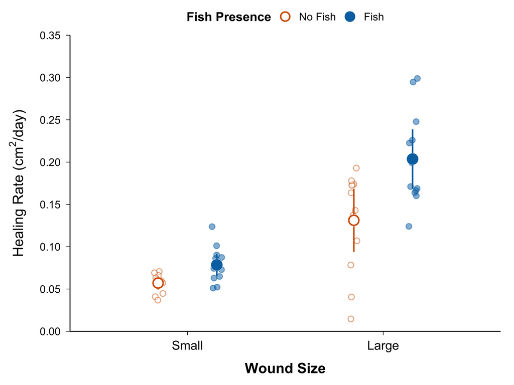

```r
# Drop unused factor levels for proper positioning
percent_closure_plot <- percent_closure %>%
  mutate(wound = droplevels(wound))

# Calculate summary statistics for plotting
healing_summary <- percent_closure_plot %>%
  group_by(wound, fish) %>%
  summarize(
    mean_val = mean(healing_rate),
    sd_val = sd(healing_rate),
    n = n(),
    se = sd_val / sqrt(n),
    ci = qt(0.975, df = n - 1) * se,
    ci_lower = mean_val - ci,
    ci_upper = mean_val + ci,
    .groups = "drop"
  )

# Define gap size around mean point (in data units)
# This creates space so whiskers don't pass through the mean point
gap_size <- 0.006  # Adjust based on y-axis scale

# Create publication-quality figure
# Grayscale compatible: No Fish = white fill, Fish = dark fill
healing_plot <- percent_closure_plot %>%
  ggplot(aes(x = wound, y = healing_rate, color = fish, fill = fish, shape = fish)) +

  # Individual data points with solid white fill for No Fish
  geom_jitter(
    position = position_jitterdodge(jitter.width = 0.1, dodge.width = 0.6),
    size = 2.5,
    alpha = 0.5,
    stroke = 0.8
  ) +

  # Lower whisker (from CI lower bound to just below mean)
  geom_segment(
    data = healing_summary,
    aes(x = as.numeric(wound) + ifelse(fish == "No Fish", -0.15, 0.15),
        xend = as.numeric(wound) + ifelse(fish == "No Fish", -0.15, 0.15),
        y = ci_lower, yend = mean_val - gap_size,
        color = fish),
    linewidth = 0.8,
    inherit.aes = FALSE,
    show.legend = FALSE
  ) +

  # Upper whisker (from just above mean to CI upper bound)
  geom_segment(
    data = healing_summary,
    aes(x = as.numeric(wound) + ifelse(fish == "No Fish", -0.15, 0.15),
        xend = as.numeric(wound) + ifelse(fish == "No Fish", -0.15, 0.15),
        y = mean_val + gap_size, yend = ci_upper,
        color = fish),
    linewidth = 0.8,
    inherit.aes = FALSE,
    show.legend = FALSE
  ) +

  # White outline behind mean points for visibility
  geom_point(
    data = healing_summary,
    aes(x = as.numeric(wound) + ifelse(fish == "No Fish", -0.15, 0.15),
        y = mean_val),
    size = 5.5,
    color = "white",
    inherit.aes = FALSE,
    show.legend = FALSE
  ) +

  # Mean points with solid fill
  geom_point(
    data = healing_summary,
    aes(x = as.numeric(wound) + ifelse(fish == "No Fish", -0.15, 0.15),
        y = mean_val, color = fish, fill = fish, shape = fish),
    size = 4.5,
    stroke = 1.2,
    inherit.aes = FALSE
  ) +

  # Scales - colorblind-safe with high contrast
  scale_color_manual(
    values = c("No Fish" = "#D55E00", "Fish" = "#0072B2"),
    name = "Fish Presence"
  ) +
  scale_fill_manual(
    values = c("No Fish" = "white", "Fish" = "#0072B2"),
    name = "Fish Presence"
  ) +
  scale_shape_manual(
    values = c("No Fish" = 21, "Fish" = 21),  # Both use fillable circles
    name = "Fish Presence"
  ) +
  scale_y_continuous(
    limits = c(0, 0.35),
    breaks = seq(0, 0.35, by = 0.05),
    expand = c(0, 0)
  ) +

  # Theme - publication quality
  theme_minimal(base_size = 14) +
  theme(
    panel.grid = element_blank(),
    axis.title.x = element_text(size = 16, face = "bold", margin = margin(t = 12)),
    axis.title.y = element_text(size = 16, face = "bold", margin = margin(r = 12)),
    axis.text.x = element_text(size = 14, color = "black"),
    axis.text.y = element_text(size = 12, color = "black"),
    legend.position = "top",
    legend.title = element_text(size = 14, face = "bold"),
    legend.text = element_text(size = 12),
    legend.key.size = unit(1.2, "lines"),
    legend.margin = margin(0, 0, 8, 0),
    legend.box.spacing = unit(0.3, "lines"),
    legend.background = element_rect(fill = "white", color = NA),
    axis.line = element_line(color = "black", linewidth = 0.5),
    axis.ticks = element_line(color = "black", linewidth = 0.3),
    axis.ticks.length = unit(0.15, "cm"),
    plot.margin = margin(10, 15, 10, 10)
  ) +
  labs(
    y = expression("Healing Rate (cm"^2*"/day)"),
    x = "Wound Size"
  ) +
  guides(
    color = guide_legend(override.aes = list(size = 4, alpha = 1)),
    fill = guide_legend(override.aes = list(size = 4, alpha = 1)),
    shape = guide_legend(override.aes = list(size = 4, alpha = 1))
  )

# Display plot
print(healing_plot)
```

```r
# Save as PDF (vector, print-quality)
ggsave(
  filename = here("figures", "wound_closure", "summary_line_healing_rate_by_wound_fish.pdf"),
  plot = healing_plot,
  width = 7,
  height = 5,
  dpi = 600,
  device = cairo_pdf
)

# Save as PNG (raster, screen-quality)
ggsave(
  filename = here("figures", "wound_closure", "summary_line_healing_rate_by_wound_fish.png"),
  plot = healing_plot,
  width = 8,
  height = 6,
  dpi = 300,
  bg = "white"
)

cat("✓ Figure saved to figures/wound_closure/\n")
```

```
## ✓ Figure saved to figures/wound_closure/
```

# 6. Summary Statistics by Treatment

```r
# Wound size effect
rate_avg_wound <- percent_closure %>%
  group_by(wound) %>%
  summarize(
    mean_rate = mean(healing_rate, na.rm = TRUE),
    sd_rate = sd(healing_rate, na.rm = TRUE),
    n = n(),
    .groups = "drop"
  )

cat("=== Healing Rate by Wound Size ===\n")
```

```
## === Healing Rate by Wound Size ===
```

```r
print(rate_avg_wound)
```

```
## # A tibble: 2 × 4
##   wound mean_rate sd_rate     n
##   <fct>     <dbl>   <dbl> <int>
## 1 Small    0.0682  0.0199    23
## 2 Large    0.167   0.0669    24
```

```r
# Fish presence effect
rate_avg_fish <- percent_closure %>%
  group_by(fish) %>%
  summarize(
    mean_rate = mean(healing_rate, na.rm = TRUE),
    sd_rate = sd(healing_rate, na.rm = TRUE),
    n = n(),
    .groups = "drop"
  )

cat("\n=== Healing Rate by Fish Presence ===\n")
```

```
##
## === Healing Rate by Fish Presence ===
```

```r
print(rate_avg_fish)
```

```
## # A tibble: 2 × 4
##   fish    mean_rate sd_rate     n
##   <fct>       <dbl>   <dbl> <int>
## 1 No Fish    0.0957  0.0566    23
## 2 Fish       0.141   0.0759    24
```

```r
# Interaction: Fish × Wound
rate_avg_interaction <- percent_closure %>%
  group_by(fish, wound) %>%
  summarize(
    mean_rate = mean(healing_rate, na.rm = TRUE),
    sd_rate = sd(healing_rate, na.rm = TRUE),
    n = n(),
    .groups = "drop"
  )

cat("\n=== Healing Rate by Fish × Wound ===\n")
```

```
##
## === Healing Rate by Fish × Wound ===
```

```r
print(rate_avg_interaction)
```

```
## # A tibble: 4 × 5
##   fish    wound mean_rate sd_rate     n
##   <fct>   <fct>     <dbl>   <dbl> <int>
## 1 No Fish Small    0.0570  0.0114    11
## 2 No Fish Large    0.131   0.0586    12
## 3 Fish    Small    0.0785  0.0208    12
## 4 Fish    Large    0.204   0.0553    12
```

# 6b. Left-Censoring Sensitivity Check (R1.2)

## Rationale

Reviewer 1 asked whether any wounds reached complete closure (0 cm²) before day 21. When that happens, the healing rate calculated as `(initial − final) / 21` is biased downward, because the wound stopped shrinking partway through and we are still dividing by 21 days. We document the pattern here and discuss its direction.

## Closure cross-tab

```r
closure_xtab <- percent_closure %>%
  filter(wound != "No Wound") %>%
  mutate(fully_closed = wound_size_final == 0) %>%
  count(fish, wound, fully_closed) %>%
  pivot_wider(
    names_from = fully_closed,
    values_from = n,
    values_fill = 0,
    names_prefix = "closed_"
  )

closure_xtab %>%
  gt() %>%
  tab_header(
    title = "Fragments reaching full closure (0 cm²) by day 21",
    subtitle = "Counts by treatment"
  ) %>%
  cols_label(
    fish = "Fish",
    wound = "Wound size",
    closed_FALSE = "Still open",
    closed_TRUE = "Fully closed"
  )
```

Fragments reaching full closure (0 cm²) by day 21

Counts by treatment

| Fish | Wound size | Still open | Fully closed |
| --- | --- | --- | --- |
| No Fish | Small | 5 | 6 |
| No Fish | Large | 9 | 3 |
| Fish | Small | 4 | 8 |
| Fish | Large | 4 | 8 |

```r
cat("\nTotal fully closed: ",
    sum(closure_xtab$closed_TRUE), " / ",
    sum(closure_xtab$closed_TRUE) + sum(closure_xtab$closed_FALSE),
    " wounded fragments\n", sep = "")
```

```
##
## Total fully closed: 25 / 47 wounded fragments
```

## Interpretation

The censoring pattern is concentrated in the fish-present treatments (8/12 closed in Fish/Small and Fish/Large) and rarest in the no-fish/large treatment (only 3/12). Because the calculated rate uses a fixed 21-day denominator, it **underestimates** the true healing rate for the 25 fragments that reached zero before day 21 — and the underestimation is concentrated in the fish-present cells. The fish effect we report is therefore **conservative**: with a censoring-aware estimator the fish effect would be larger, not smaller.

The full day-of-closure time series exists only for the daily-photographed subset (one fragment per wound × tank). A formal Cox-style or interval-censored re-analysis on that subset would tighten the inference and is a target for a future study with daily photography on all fragments.

# 6c. Turf-Algae Persistence: Fisher’s Exact Test (R1.4)

## Rationale

The manuscript reports parenthetically that turf algae persisted on 7 of 8 algae-colonized corals in no-fish tanks and 1 of 8 in fish tanks by day 21. Reviewer 1 asked for a formal test. We pull algae status from the PAM dataset (which records `algae` per coral at day 21) and run a Fisher’s exact test on the 2 × 2 contingency among the 48 **wounded** corals.

```r
# Load algae status from PAM dataset and restrict to wounded corals
pam_for_algae <- read_csv(
  here("data", "pam_undisturbed_healed_tissue_wound_no_wound.csv"),
  show_col_types = FALSE
) %>%
  clean_names() %>%
  filter(wound != "No Wound") %>%
  mutate(
    algae_status = ifelse(algae == "yes", "persisted", "cleared")
  )

# 2x2 contingency (fish × algae status)
tab_algae <- with(pam_for_algae, table(fish, algae_status))
print(tab_algae)
```

```
##          algae_status
## fish      cleared persisted
##   Fish         23         1
##   No Fish      17         7
```

```r
# Two-tailed Fisher's exact test
fisher_algae <- fisher.test(tab_algae, alternative = "two.sided")
print(fisher_algae)
```

```
##
##  Fisher's Exact Test for Count Data
##
## data:  tab_algae
## p-value = 0.04792
## alternative hypothesis: true odds ratio is not equal to 1
## 95 percent confidence interval:
##    1.013912 443.848629
## sample estimates:
## odds ratio
##   9.081111
```

```r
# Formatted report
fisher_summary <- tibble(
  Test = "Fisher's exact (fish × algae persistence, wounded corals only)",
  `Odds Ratio` = round(fisher_algae$estimate, 3),
  `95% CI` = paste0("[",
                    round(fisher_algae$conf.int[1], 3), ", ",
                    round(fisher_algae$conf.int[2], 3), "]"),
  `p-value` = format.pval(fisher_algae$p.value, digits = 3)
)

fisher_summary %>%
  gt() %>%
  tab_header(
    title = "Turf algae persistence by fish treatment (day 21)",
    subtitle = "Wounded corals only (n = 48)"
  )
```

Turf algae persistence by fish treatment (day 21)

Wounded corals only (n = 48)

| Test | Odds Ratio | 95% CI | p-value |
| --- | --- | --- | --- |
| Fisher's exact (fish × algae persistence, wounded corals only) | 9.081 | [1.014, 443.849] | 0.0479 |

## Mechanism discussion (for prose)

The design cannot separate two non-mutually-exclusive mechanisms for this effect: 1. Fish directly excluding algae via territorial behaviour or grazing. 2. Faster wound closure in fish-present treatments shortening the window during which exposed substrate is available for algal colonization.

Both pathways predict the observed pattern; resolving their relative contribution would require a design that decouples healing rate from the presence of the resident fish (e.g., fish present briefly then removed).

# 7. Model Diagnostics

## DHARMa Residual Diagnostics

```r
library(DHARMa)

# Simulate residuals for full model
sim_rate_full <- simulateResiduals(fittedModel = rate_full, n = 1000)

# Save DHARMa diagnostic plot
png(
  here("figures", "diagnostics", "sim_rate_full.png"),
  width = 7, height = 6, units = "in", res = 600, bg = "white"
)
plot(sim_rate_full, main = "DHARMa Diagnostics: Full Model")
dev.off()
```

```r
# Statistical tests
cat("\n=== Dispersion Test ===\n")
```

```
##
## === Dispersion Test ===
```

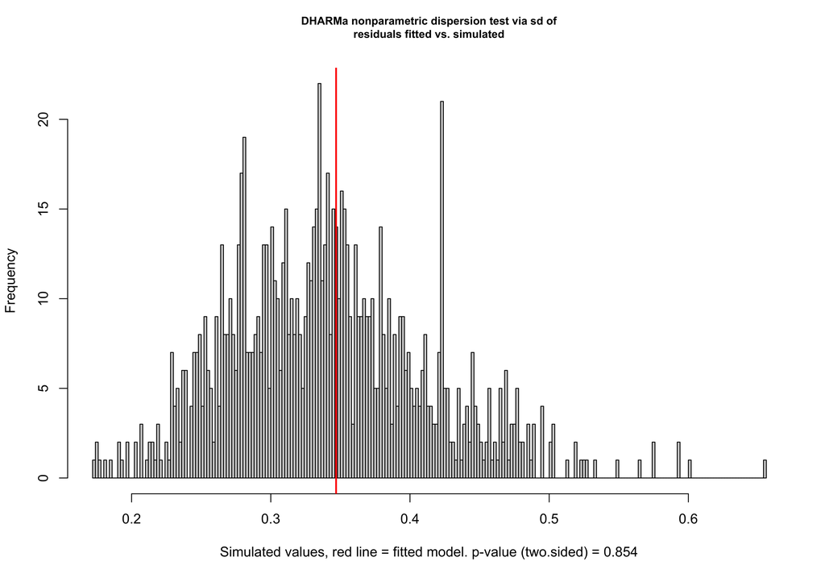

```
##
##  DHARMa nonparametric dispersion test via sd of residuals fitted vs.
##  simulated
##
## data:  simulationOutput
## dispersion = 1.0178, p-value = 0.854
## alternative hypothesis: two.sided
```

```r
print(testDispersion(sim_rate_full))
```

```r
cat("\n=== Zero-Inflation Test ===\n")
```

```
##
## === Zero-Inflation Test ===
```

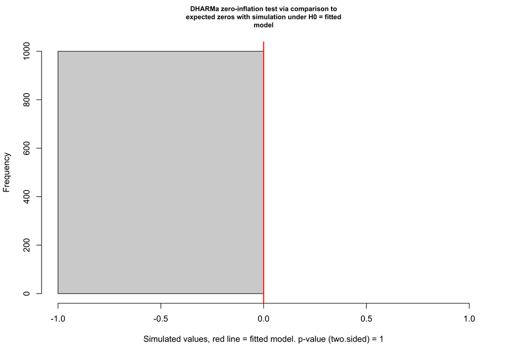

```
##
##  DHARMa zero-inflation test via comparison to expected zeros with
##  simulation under H0 = fitted model
##
## data:  simulationOutput
## ratioObsSim = NaN, p-value = 1
## alternative hypothesis: two.sided
```

```r
print(testZeroInflation(sim_rate_full))
```

## Diagnostics for All Candidate Models

```
##
## ========== Diagnostics for Full model ==========
```

```
##
##   Dispersion test:
```

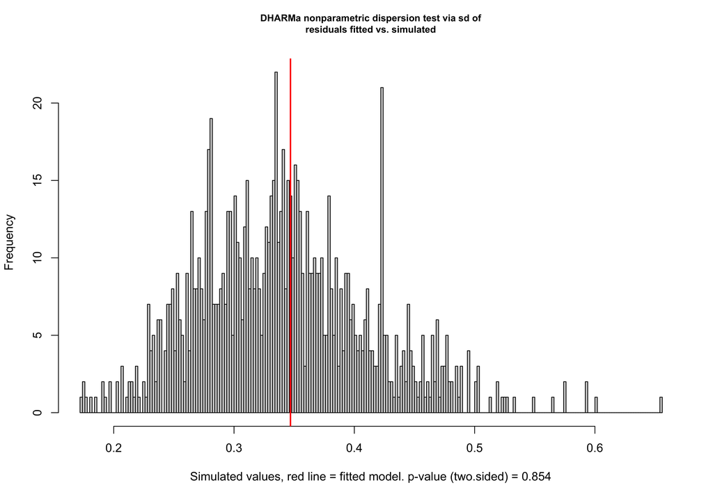

```
##
##  DHARMa nonparametric dispersion test via sd of residuals fitted vs.
##  simulated
##
## data:  simulationOutput
## dispersion = 1.0178, p-value = 0.854
## alternative hypothesis: two.sided
##
##
##   Outlier test:
```

```
##
##  DHARMa outlier test based on exact binomial test with approximate
##  expectations
##
## data:  sim
## outliers at both margin(s) = 1, observations = 47, p-value = 0.08972
## alternative hypothesis: true probability of success is not equal to 0.001998002
## 95 percent confidence interval:
##  0.0005385317 0.1129377171
## sample estimates:
## frequency of outliers (expected: 0.001998001998002 )
##                                            0.0212766
##
##
## ========== Diagnostics for NoInteraction model ==========
```

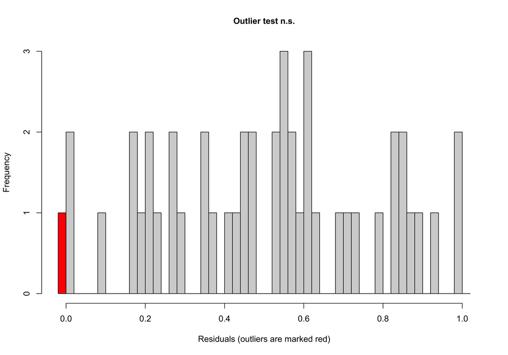

```
##
##   Dispersion test:
```

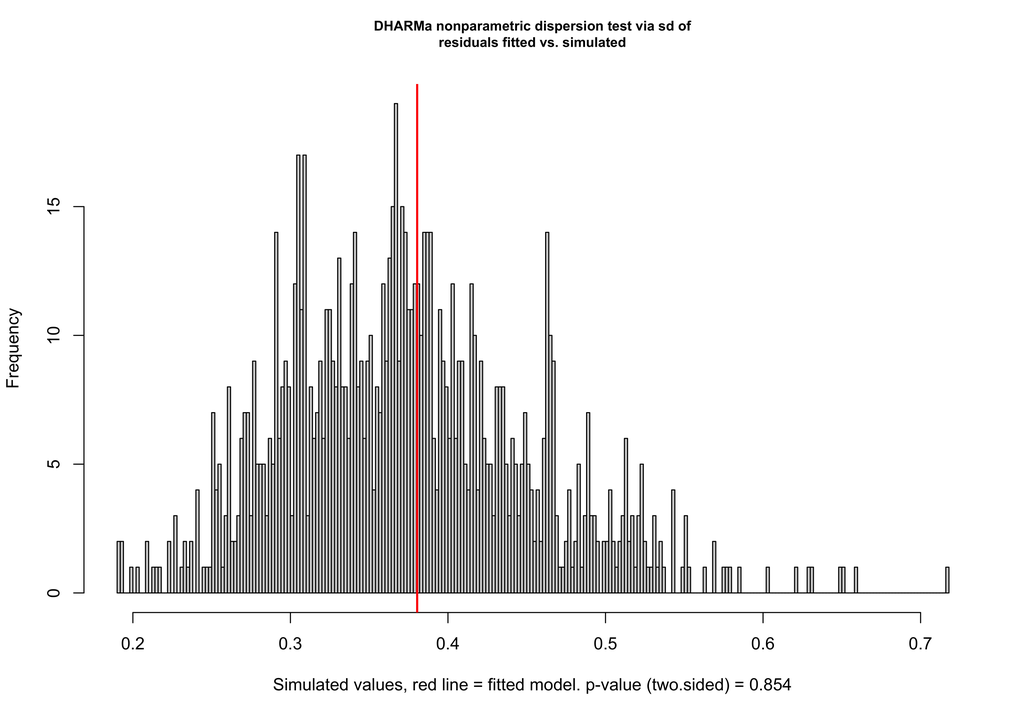

```
##
##  DHARMa nonparametric dispersion test via sd of residuals fitted vs.
##  simulated
##
## data:  simulationOutput
## dispersion = 1.0178, p-value = 0.854
## alternative hypothesis: two.sided
##
##
##   Outlier test:
```

```
##
##  DHARMa outlier test based on exact binomial test with approximate
##  expectations
##
## data:  sim
## outliers at both margin(s) = 1, observations = 47, p-value = 0.08972
## alternative hypothesis: true probability of success is not equal to 0.001998002
## 95 percent confidence interval:
##  0.0005385317 0.1129377171
## sample estimates:
## frequency of outliers (expected: 0.001998001998002 )
##                                            0.0212766
##
##
## ========== Diagnostics for NoFish model ==========
```

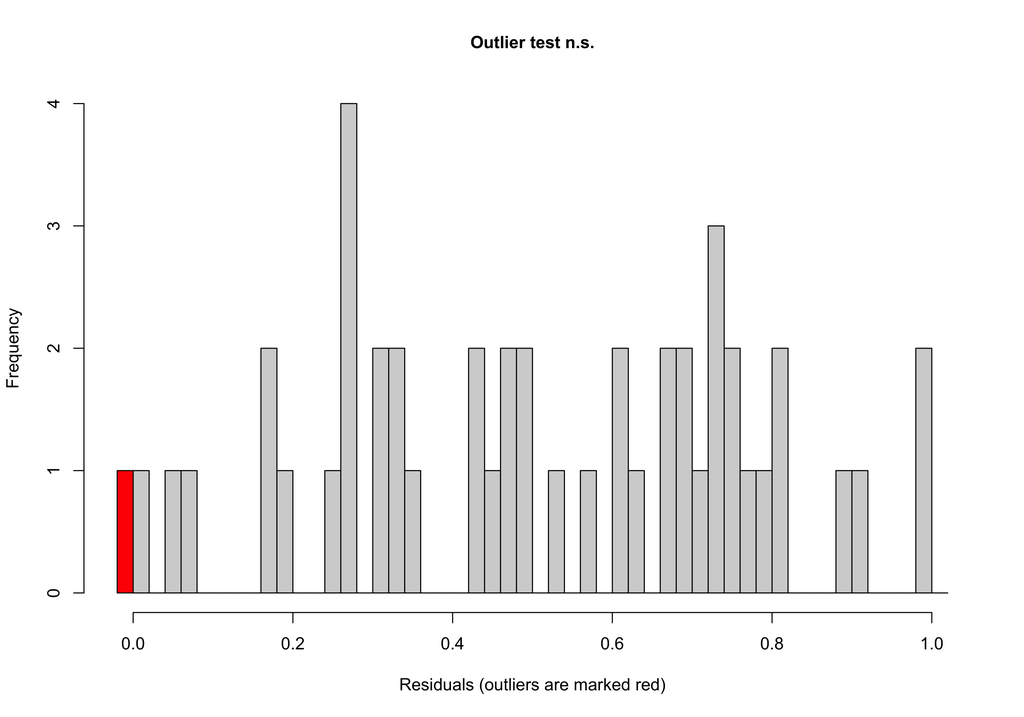

```
##
##   Dispersion test:
```

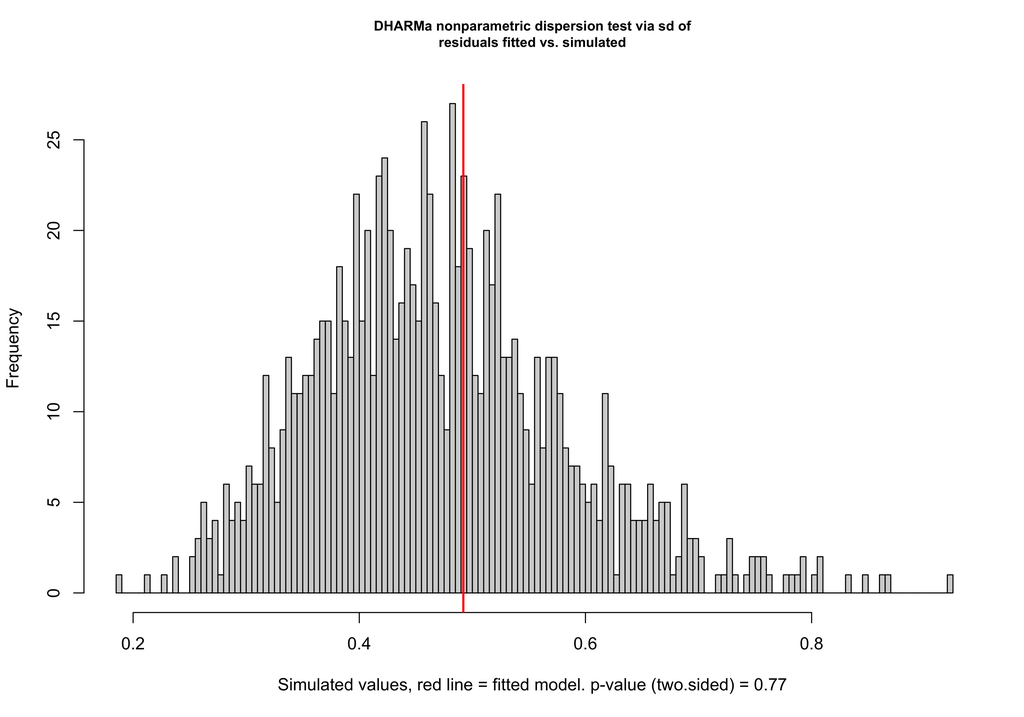

```
##
##  DHARMa nonparametric dispersion test via sd of residuals fitted vs.
##  simulated
##
## data:  simulationOutput
## dispersion = 1.046, p-value = 0.77
## alternative hypothesis: two.sided
##
##
##   Outlier test:
```

```
##
##  DHARMa outlier test based on exact binomial test with approximate
##  expectations
##
## data:  sim
## outliers at both margin(s) = 2, observations = 47, p-value = 0.004065
## alternative hypothesis: true probability of success is not equal to 0.001998002
## 95 percent confidence interval:
##  0.005195583 0.145405245
## sample estimates:
## frequency of outliers (expected: 0.001998001998002 )
##                                           0.04255319
##
##
## ========== Diagnostics for NoWound model ==========
```

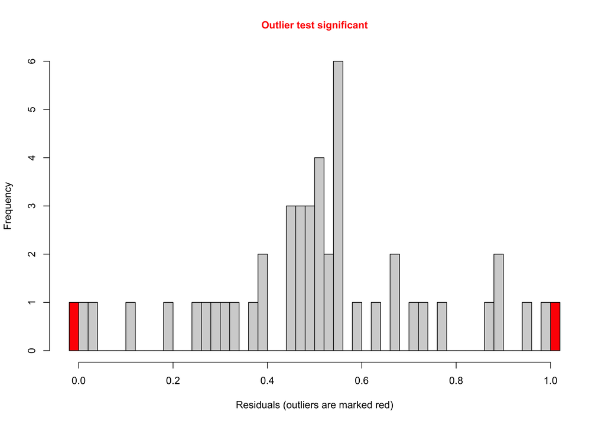

```
##
##   Dispersion test:
```

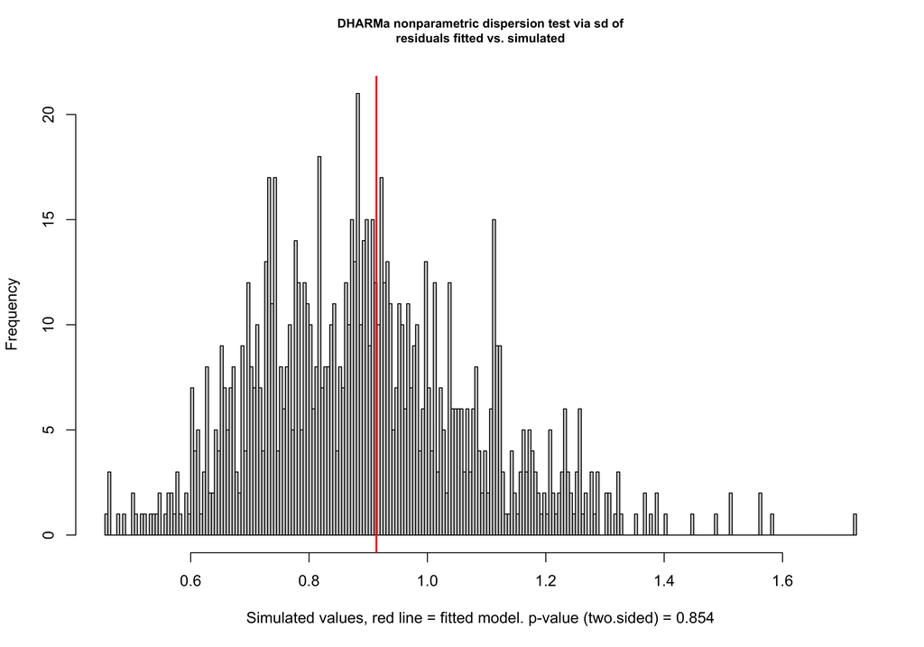

```
##
##  DHARMa nonparametric dispersion test via sd of residuals fitted vs.
##  simulated
##
## data:  simulationOutput
## dispersion = 1.0178, p-value = 0.854
## alternative hypothesis: two.sided
##
##
##   Outlier test:
```

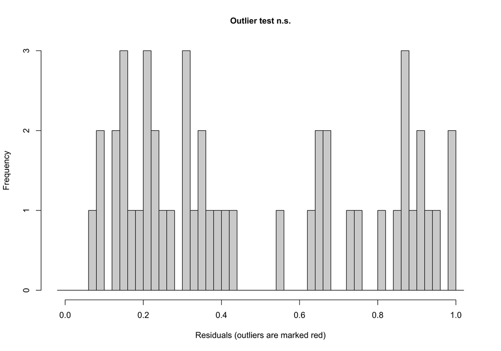

```
##
##  DHARMa outlier test based on exact binomial test with approximate
##  expectations
##
## data:  sim
## outliers at both margin(s) = 0, observations = 47, p-value = 1
## alternative hypothesis: true probability of success is not equal to 0.001998002
## 95 percent confidence interval:
##  0.00000000 0.07548573
## sample estimates:
## frequency of outliers (expected: 0.001998001998002 )
##                                                    0
```

```r
model_list <- list(
  Full = rate_full,
  NoInteraction = rate_no_interaction,
  NoFish = rate_no_fish,
  NoWound = rate_no_wound
)

for (nm in names(model_list)) {
  cat("\n========== Diagnostics for", nm, "model ==========\n")
  sim <- simulateResiduals(model_list[[nm]], n = 1000)

  # Save DHARMa plot
  png(
    here("figures", "diagnostics", paste0("resid_", nm, ".png")),
    width = 7, height = 6, units = "in", res = 600, bg = "white"
  )
  plot(sim, main = paste("DHARMa Diagnostics:", nm, "Model"))
  dev.off()

  # Print test results
  cat("\n  Dispersion test:\n")
  print(testDispersion(sim))
  cat("\n  Outlier test:\n")
  print(testOutliers(sim))
}
```

```r
cat("\n✓ All diagnostic plots saved to figures/diagnostics/\n")
```

```
##
## ✓ All diagnostic plots saved to figures/diagnostics/
```

## Predicted vs Observed

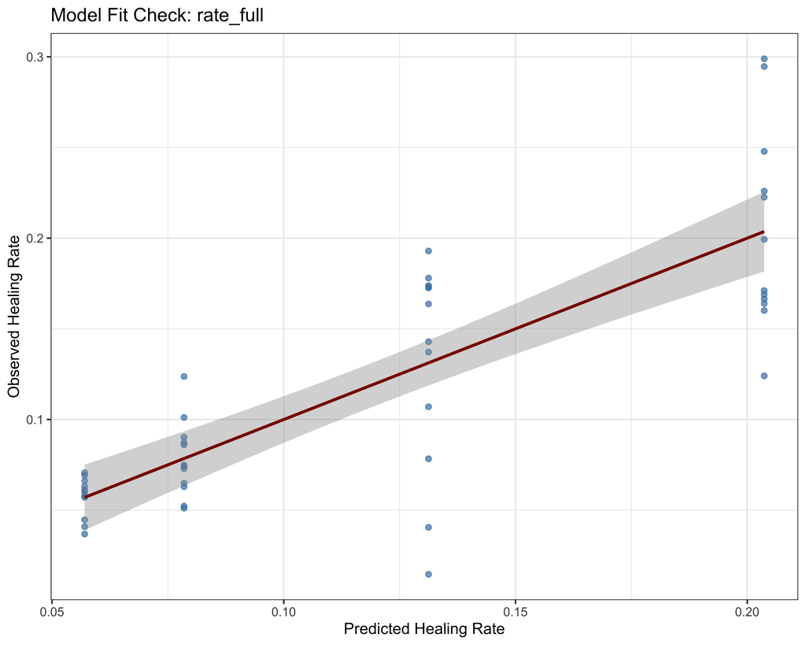

```r
# Add predictions to data
percent_closure$pred_full <- predict(rate_full)

# Create scatterplot
p_fit <- ggplot(percent_closure, aes(x = pred_full, y = healing_rate)) +
  geom_point(color = "steelblue", size = 2, alpha = 0.7) +
  geom_smooth(method = "lm", se = TRUE, color = "darkred") +
  labs(
    x = "Predicted Healing Rate",
    y = "Observed Healing Rate",
    title = "Model Fit Check: rate_full"
  ) +
  theme_bw(base_size = 14)

print(p_fit)
```

```r
ggsave(
  here("figures", "diagnostics", "fit_scatterplot.png"),
  p_fit,
  width = 10, height = 8, dpi = 300, bg = "white"
)
```

## Residual Diagnostic Panel

```r
library(patchwork)

# Residuals vs index
p_resid_plot <- ggplot(
  data.frame(resid = residuals(rate_full, type = "pearson")),
  aes(x = seq_along(resid), y = resid)
) +
  geom_point(alpha = 0.6) +
  geom_hline(yintercept = 0, linetype = "dashed") +
  theme_minimal() +
  labs(title = "Pearson Residuals", x = "Observation", y = "Residual")

# Residuals vs fitted
p_fit_plot <- ggplot(
  data.frame(fitted = fitted(rate_full),
             resid = residuals(rate_full, type = "pearson")),
  aes(x = fitted, y = resid)
) +
  geom_point(alpha = 0.6) +
  geom_hline(yintercept = 0, linetype = "dashed") +
  theme_minimal() +
  labs(title = "Residuals vs Fitted", x = "Fitted values", y = "Residuals")

# Combine panels
p_resid_panel <- (p_resid_plot | p_fit_plot) +
  plot_annotation(
    title = "Residual Diagnostics for Healing Rate Models",
    theme = theme(plot.title = element_text(size = 18, face = "bold"))
  )

print(p_resid_panel)
```

[figure not shown]

```r
# Save panel
ggsave(
  here("figures","diagnostics","healing_rate_diagnostics_panel.png"),
  p_resid_panel,
  width = 14, height = 7, dpi = 300, bg = "white"
)
```

## QQ-Plot for Normality

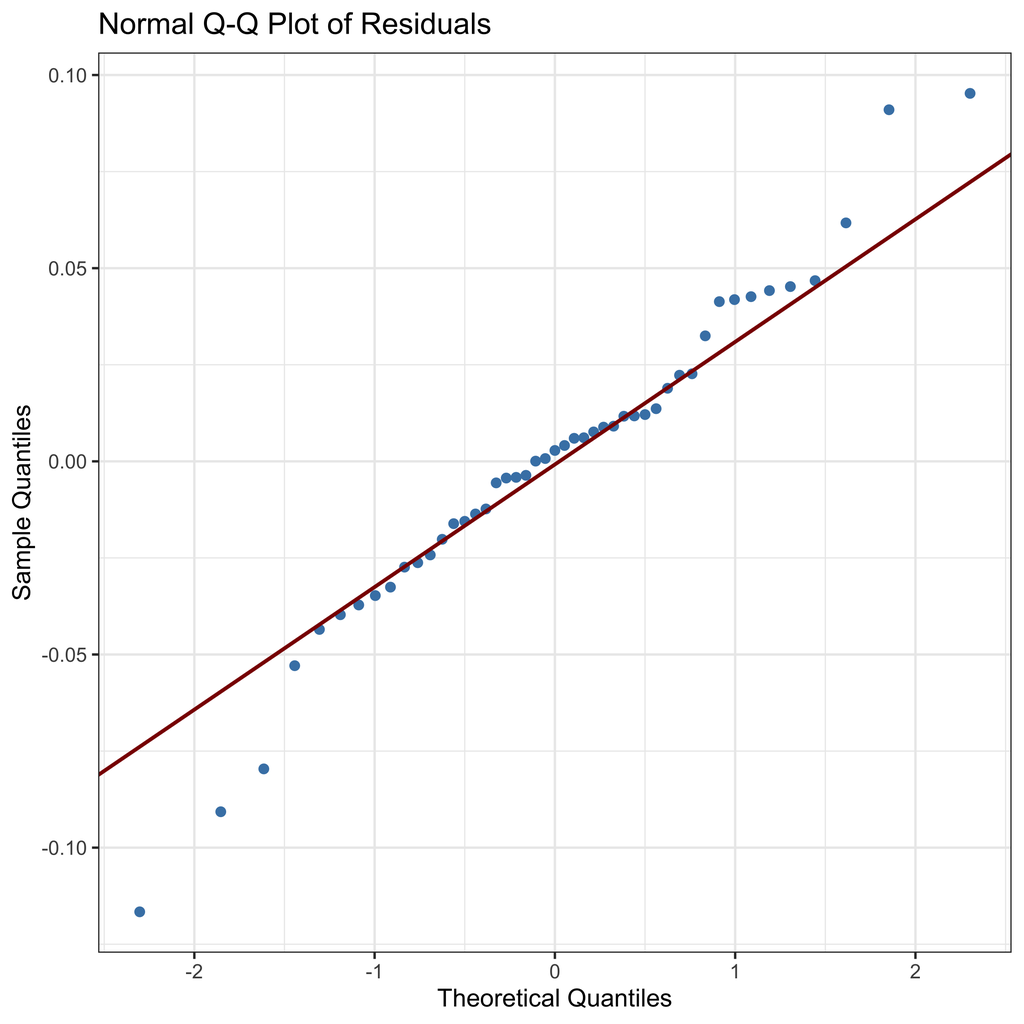

```r
p_qq <- ggplot(
  data.frame(resid = residuals(rate_full, type = "pearson")),
  aes(sample = resid)
) +
  stat_qq(color = "steelblue", size = 2) +
  stat_qq_line(color = "darkred", linewidth = 1) +
  theme_bw(base_size = 14) +
  labs(
    title = "Normal Q-Q Plot of Residuals",
    x = "Theoretical Quantiles",
    y = "Sample Quantiles"
  )

print(p_qq)
```

```r
ggsave(
  here("figures", "diagnostics", "qq_plot_residuals.png"),
  p_qq,
  width = 8, height = 8, dpi = 300, bg = "white"
)
```

## Scale-Location Plot

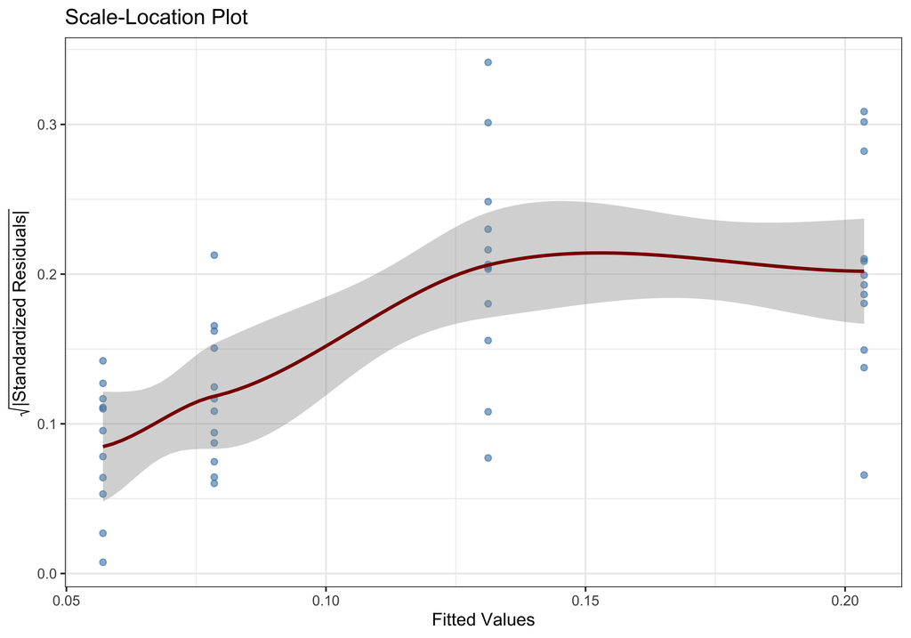

```r
p_scale_loc <- ggplot(
  data.frame(
    fitted = fitted(rate_full),
    sqrt_abs_resid = sqrt(abs(residuals(rate_full, type = "pearson")))
  ),
  aes(x = fitted, y = sqrt_abs_resid)
) +
  geom_point(alpha = 0.6, color = "steelblue", size = 2) +
  geom_smooth(se = TRUE, color = "darkred", method = "loess") +
  theme_bw(base_size = 14) +
  labs(
    title = "Scale-Location Plot",
    x = "Fitted Values",
    y = expression(sqrt("|Standardized Residuals|"))
  )

print(p_scale_loc)
```

```r
ggsave(
  here("figures", "diagnostics", "scale_location_plot.png"),
  p_scale_loc,
  width = 10, height = 7, dpi = 300, bg = "white"
)
```

## Diagnostic Summary Statistics

```r
cat("\n=== Model Diagnostics Summary ===\n")
```

```
##
## === Model Diagnostics Summary ===
```

```r
cat("\nResidual standard deviation:", sigma(rate_full), "\n")
```

```
##
## Residual standard deviation: 0.04058408
```

```r
cat("Number of observations:", nobs(rate_full), "\n")
```

```
## Number of observations: 47
```

```r
cat("\nResidual summary statistics:\n")
```

```
##
## Residual summary statistics:
```

```r
print(summary(residuals(rate_full, type = "pearson")))
```

```
##      Min.   1st Qu.    Median      Mean   3rd Qu.      Max.
## -0.116611 -0.022206  0.002818  0.000000  0.020603  0.095246
```

```r
# Check for influential observations
cat("\n\n=== Checking for Influential Observations ===\n")
```

```
##
##
## === Checking for Influential Observations ===
```

```r
influence_measures <- influence(rate_full, obs = TRUE)
cat("Cook's distance threshold (4/n):", 4/nobs(rate_full), "\n")
```

```
## Cook's distance threshold (4/n): 0.08510638
```

**Analysis Complete** ✓

All figures and tables saved to `figures/` directory.